# R Notebook

## In this homework, you need to implement a linear regression model and answer the followed questions.

## 1. Load Boston.cvs data set. It records 14 variables for 506 neighborhoods around Boston

## crim: per capita crime rate by town.

## zn: proportion of residential land zoned for lots over 25,000 sq.ft.

## indus: proportion of non-retail business acres per town.

## chas: Charles River dummy variable (= 1 if tract bounds river; 0 otherwise).

## nox: nitrogen oxides concentration (parts per 10 million).

## rm: average number of rooms per dwelling.

## age: proportion of owner-occupied units built prior to 1940.

## dis: weighted mean of distances to five Boston employment centers.

## rad: index of accessibility to radial highways. tax: full-value property-tax rate per $10,000. ptratio: pupil-teacher ratio by town.

## black: 1000(Bk - 0.63)^2 where Bk is the proportion of blacks by town.

## lstat: lower status of the population (percent).

## medv: median value of owner-occupied homes in $1000s.

```r
directory <- getwd()

boston <- read.csv("Boston.csv", sep = ',')

str(boston)

names(boston)
```

[output not shown]

## 2. Fit a multiple regression model to predict the response variable medv using all other variables. For which variables the corresponding regression coefficients are likely to be significant? (40 points)

```r
## Split the data into train and test set
# for reproducing results
set.seed(123)
sample.size <- floor(0.75 * nrow(boston))
train.index <- sample(seq_len(nrow(boston)), size = sample.size)
train <- boston[train.index, ]
test <- boston[- train.index, ]

# fit a multiple linear regression model
multi_lm_fit = lm(medv ~ lstat + age,data = train)
summary(multi_lm_fit)
```

[output not shown]

## 3. On the basis of your response to the previous question, fit a smaller linear regression model that only uses predictors for which there is evidence of association with medv. (10 points)

```r
# fit a simple linear regression model

lm_fit = lm(medv ~ lstat, data = train)
summary(lm_fit)
```

[output not shown]

## 4. How well the models in 2 and 3 fit the data? (10 points)

# We can see that in multiple regression model i.e (2) we are able to establish the relationship between multiple interrelated variables.While incase of a linear regression model we are able to establish the relationship between two variables.The first case is most widely used as in real world we have scenarios to find the relationship between multiple values.

## 5. Try to reduce the set of predictors by making correlation and scatterplot matrices and fit even a smaller model using the predictors of your choice. (30 points)

```r
## For Multiple Regression
multi_lm_fit = lm(medv ~ lstat * age, data = boston)
## Prediction
head(predict(multi_lm_fit, test, interval = "confidence"), 5)
```

```
         fit      lwr       upr
6  30.064295 29.24880 30.879786
8  17.008484 16.20105 17.815917
9   6.789157  5.11536  8.462954
10 18.326052 17.64612 19.005985
18 20.588358 19.93425 21.242464
```

```r
head(predict(multi_lm_fit, test, interval = "prediction"), 5)
```

```
         fit       lwr      upr
6  30.064295 17.956811 42.17178
8  17.008484  4.901541 29.11543
9   6.789157 -5.406241 18.98455
10 18.326052  6.226943 30.42516
18 20.588358  8.490673 32.68604
```

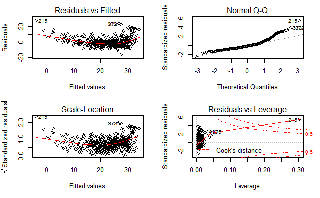

```r
## Diagnostic Plot
par(mfrow = c(2,2))
plot(multi_lm_fit)
```

```r
##For Linear Regression
## Prediction
head(predict(lm_fit, test, interval = "confidence"), 5)
```

```
         fit       lwr       upr
6  29.535867 28.631219 30.440516
8  16.431071 15.567267 17.294874
9   6.296945  4.620566  7.973325
10 18.358247 17.607999 19.108494
18 20.642655 19.985224 21.300087
```

```r
head(predict(lm_fit, test, interval = "prediction"), 5)
```

```
         fit       lwr      upr
6  29.535867 17.267822 41.80391
8  16.431071  4.165969 28.69617
9   6.296945 -6.052014 18.64591
10 18.358247  6.100619 30.61587
18 20.642655  8.390359 32.89495
```

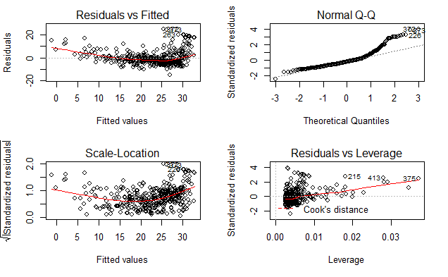

```r
## Scatter Plot
par(mfrow = c(2,2))
plot(lm_fit)
```

## 6. Investigate possible interactions between the variables in the last model. Try to find a model with the maximum of R2 value (10 points)

```r
##Given a predictor X, we can create predictor X2 using I(X^2).
lm.fit = lm(medv ~ crim + rm + dis + ptratio +  chas + nox + black + lstat + I(lstat ^ 2), data=train)
summary(lm.fit)
```

```
Call:
lm(formula = medv ~ crim + rm + dis + ptratio + chas + nox +
    black + lstat + I(lstat^2), data = train)

Residuals:
     Min       1Q   Median       3Q      Max
-18.2337  -2.6950  -0.4378   1.7613  25.5685

Coefficients:
              Estimate Std. Error t value Pr(>|t|)
(Intercept)  37.095399   5.080930   7.301 1.77e-12 ***
crim         -0.080073   0.034204  -2.341 0.019760 *
rm            3.322814   0.433383   7.667 1.57e-13 ***
dis          -1.269777   0.182673  -6.951 1.65e-11 ***
ptratio      -0.632826   0.125327  -5.049 6.98e-07 ***
chas          3.392759   0.980433   3.460 0.000602 ***
nox         -11.033161   3.556692  -3.102 0.002070 **
black         0.006355   0.002970   2.139 0.033054 *
lstat        -1.770121   0.138387 -12.791  < 2e-16 ***
I(lstat^2)    0.035154   0.003717   9.458  < 2e-16 ***
---
Signif. codes:  0 ‘***’ 0.001 ‘**’ 0.01 ‘*’ 0.05 ‘.’ 0.1 ‘ ’ 1

Residual standard error: 4.51 on 369 degrees of freedom
Multiple R-squared:  0.7596,    Adjusted R-squared:  0.7537
F-statistic: 129.6 on 9 and 369 DF,  p-value: < 2.2e-16
```